# Study of comparative methods – Simulating data for pseudoreplication problem.

Heath Blackmon

September 15, 2015

[Return to main website](http://coleoguy.github.io/resources.html)

Return to of comparative methods [outline](http://coleoguy.github.io/comparative/methods.html) page

# simulated data - trees

```r
### Generate trees
set.phy <- list()
seed.counter <- 1
for(i in 1:100){
  tree.good <- F
  # this conditions on the tree haveing 101-199 tips
  while(tree.good == F){
    set.seed(seed.counter*3)
    phy <- diversitree::tree.bd(pars = c(1, 0.4), max.t=6)
    if(length(phy$tip.label) > 100 & length(phy$tip.label) < 200){
      set.phy[[i]] <- phy
      tree.good <- T
    }
    seed.counter <- seed.counter + 1
  }
}
rm(i, phy, seed.counter, tree.good)
```

Here is a random sample of 3 of our trees:

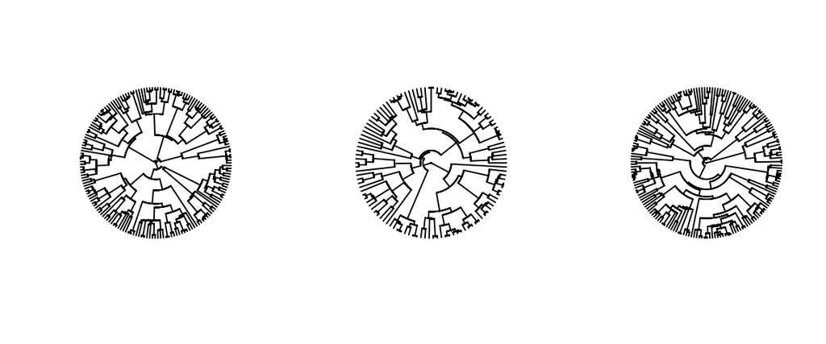

# simulated data - Darwin’s scenario states

```r
### Generate traits that mimics "Darwin's scenario"
set.state <- list()
used.nodes <- vector()
for(i in 1:100){
  data.good <- F
  # this conditions on the node where our trait changes having
  # between 30 and 60% of the species on the tree
  node.counter <- length(set.phy[[i]]$tip.label) + 1
  while(data.good == F){
    node.counter <- node.counter + 1
    descendents <- phangorn::Descendants(set.phy[[i]],
                                         node=node.counter,
                                         type="tips")[[1]]
    max.tip <- length(set.phy[[i]]$tip.label) * .60
    min.tip <- length(set.phy[[i]]$tip.label) * .30
    if(length(descendents) < max.tip & length(descendents) > min.tip){
      states <- vector(mode="numeric", length=length(set.phy[[i]]$tip.label))
      states[descendents] <- 1
      set.state[[i]] <- states
      used.nodes[i] <- node.counter
      data.good <- T
    }
  }
}
state.darwin1 <- state.darwin2 <- set.state
rm(data.good, descendents, i, max.tip, min.tip, node.counter, set.state, states)
```

Here is a random sample of 3 of our trees with Darwin’s scenario data for two traits:

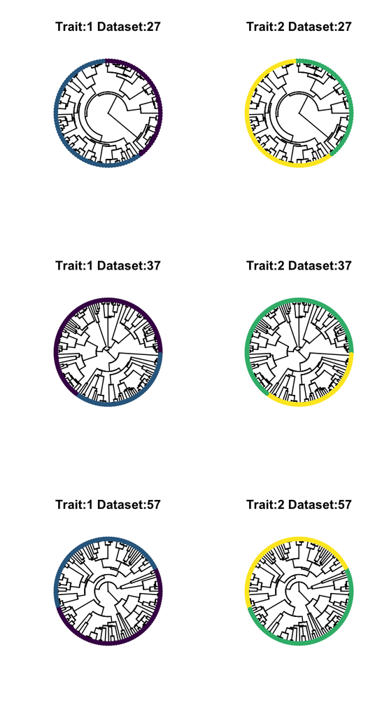

For Darwin’s scenario we only have to simulate a single dataset for each itteration and we simply duplicate it for the second trait.

# simulated data - unreplicated burst states

This type of dataset describes a situation where 1 trait has experienced a single transition on the tree (as in Darwin’s scenario) while the second trait shows many origins but only within the subtree that experienced the transition in the other trait. To simulate this data my first trait will be simulated in the same fashion as I did for Darwin’s scenario datasets above. For the second datest I will extract the subtree chosen for the first trait and evolve a trait under an Mk model with only transition out of state 0 into state 1 allowed. Acceptance of these datasets will be conditioned on 40-60% of the tips being in the derived state.

```r
### Generate traits that mimics "unreplicated burst scenario"
# first I'll take care of the trait with a single transition
set.state <- list()
for(i in 1:100){
  data.good <- F
  # this conditions on the node where our trait changes having
  # between 30 and 70% of the species on the tree
  current.tree <- ape::extract.clade(set.phy[[i]], used.nodes[i])
  while(data.good == F){
    qmat <- matrix(c(-.2,0,.2,0),2,2)
    result <- diversitree::sim.character(current.tree,
                                         c(.5,0), x0=0, model="mk2")
    transitioned <- names(which(result== 1))
    max.tip <- length(current.tree$tip.label) * .60
    min.tip <- length(current.tree$tip.label) * .40
    if(length(transitioned) < max.tip &
       length(transitioned) > min.tip){
      states <- vector(mode="numeric", length=length(set.phy[[i]]$tip.label))
      transitioned <- which(set.phy[[i]]$tip.label %in% transitioned)
      states[transitioned] <- 1
      set.state[[i]] <- states
      data.good <- T
    }
  }
}
unrepburst1 <- state.darwin1
unrepburst2 <- set.state
```

Here is a randomly chosen pair of traits for the unreplicated burst type of data:

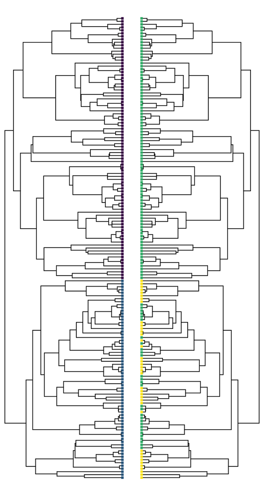

# simulated data - perfectly replicated evolution states

```r
### Generate traits that mimics "perfect replicated scenario"
set.state <- list()
for(i in 1:100){
  data.good <- F
  counter <- i
  current.tree <- set.phy[[i]]
  min.node <- length(current.tree$tip.label) + 2
  max.node <- length(current.tree$tip.label) + length(current.tree$node.label)
  # this conditions on the selected 6
  # origins each having at least 5-10 tips
  while(data.good == F){
    counter <- counter + 1
    set.seed(counter)
    picked.nodes <- sample(min.node:max.node, size=6)
    descendants <- phangorn::Descendants(set.phy[[i]], node=picked.nodes, type="tips")
    foo <- c(F,F,F,F,F,F)
    for(j in 1:6){
      if(length(descendants[[j]]) <= 15 & length(descendants[[j]]) >= 2) foo[j] <- T
    }
    if(sum(foo) == 6) data.good <- T
  }
  states <- vector(mode="numeric", length=length(set.phy[[i]]$tip.label))
  states[unlist(descendants)] <- 1
  set.state[[i]] <- states
}
perfrep1 <- perfrep2 <- set.state
```

Here is a look at what the perfectly replicated changes datasets look like:

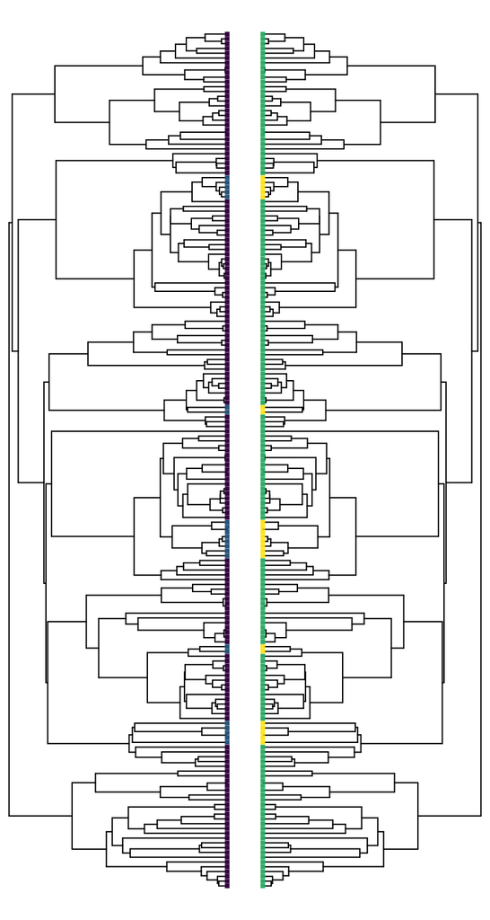

# simulated data - dependant evolution states

So this is the model that we are assuming when using Pagel’s test. One of the difficulties in simulating this dataset is that you have to pick values for 8 rates in the Mk model. I thought about drawing them randomly but then your choice of the distribution to draw from can be tweaked to make significance easier to achieve. I decided to borrow some [code from Liam](http://blog.phytools.org/2014/12/r-function-for-pagels-1994-correlation.html) where he simulated under this type of model. I think that the choice of these rates is something that should be considered in more depth later.

```r
# next ten lines of code are largely borrowed from Liams blog post on this topic
dependant.data1 <- dependant.data2 <- list()
Q<-matrix(c(0,0.5,0.5,0,2,0,0,2,2,0,0,2,0,0.5,0.5,0),4,4,byrow=TRUE)
rownames(Q)<-colnames(Q)<-c("aa","ab","ba","bb")
diag(Q)<--rowSums(Q)
for(i in 1:100){
  tt<-phytools::sim.history(set.phy[[i]],t(Q), anc="aa", message=F)
  states1 <- vector(mode="numeric", length=length(set.phy[[i]]$tip.label))
  states2 <- vector(mode="numeric", length=length(set.phy[[i]]$tip.label))
  states1[which(tt$states == "ba" | tt$states == "bb")] <- 1
  states2[which(tt$states == "ab" | tt$states == "bb")] <- 1
  dependant.data1[[i]] <- states1
  dependant.data2[[i]] <- states2
}
```

Here is a look at what the dependant datasets look like:

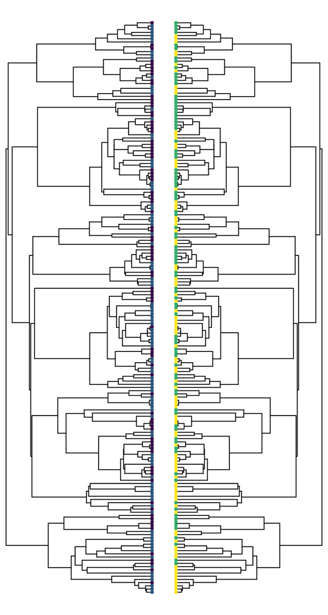

# simulated data - independant evolution states

```r
independant.data1 <- independant.data2 <- list()
for(i in 1:100){
  current.tree <- set.phy[[i]]
  independant.data1[[i]] <- diversitree::sim.character(current.tree, c(.5,.5), x0=0, model="mk2")
  independant.data2[[i]] <- diversitree::sim.character(current.tree, c(.5,.5), x0=0, model="mk2")
}
```

Here is a look at what the independant datasets look like:

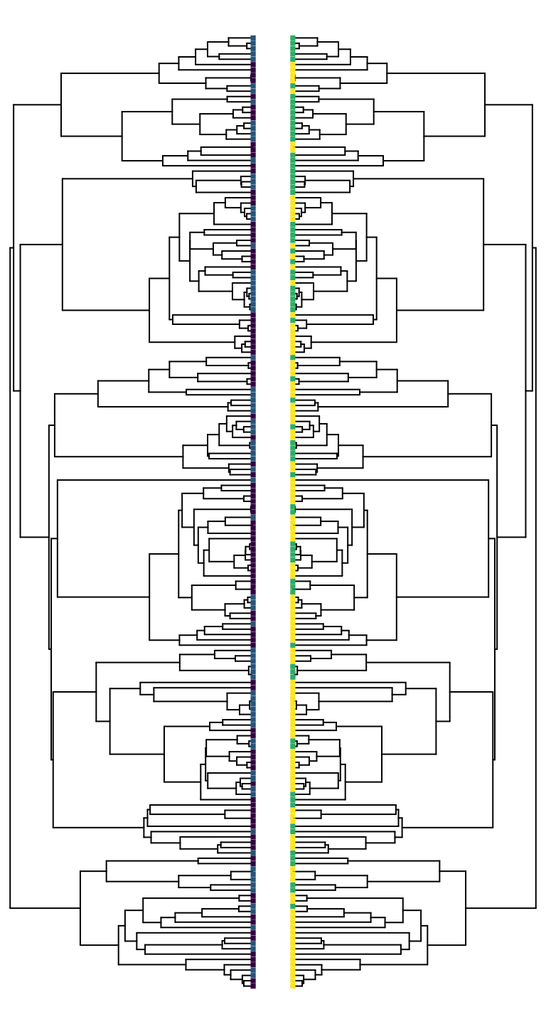

Ok lets review what we now have:

1. trees: 100 trees with 100-200 tips
2. darwins scenario data: two traits single origin identical for both traits
3. unreplicated burst data: two traits one with single origin one with many within that subtree
4. replicated evolution data = 6 identical orgins of each trait
5. dependant data = the rate of both characters are unique based on the state of the other
6. independant data = no correlation between characters

```r
save.image(file="pagel.data.sets.RData")
```

# citations

[1] Boettiger, Carl, Graham Coop, and Peter Ralph. “Is your phylogeny informative? Measuring the power of comparative methods.” Evolution 66, no. 7 (2012): 2240-2251.

[2] Maddison, Wayne P., and Richard G. FitzJohn. “The unsolved challenge to phylogenetic correlation tests for categorical characters.” Systematic biology 64, no. 1 (2015): 127-136.